# M09-2-Application-Data-Import-Export

# Question 6: Replacing values with NA

## Data

```r
data <- tibble::tribble(
  ~name,           ~x,  ~y,              ~z,
  "N/A",           1,   "N/A",           -100,
  "N A",           3,   "NOt available", -99,
  "N / A",         NA,  "29",            -98,
  "Not Available", -99, "25",            -101,
  "John Smith",    -98, "28",            -1
)

data
```

```
# A tibble: 5 × 4
  name              x y                 z
  <chr>         <dbl> <chr>         <dbl>
1 N/A               1 N/A            -100
2 N A               3 NOt available   -99
3 N / A            NA 29              -98
4 Not Available   -99 25             -101
5 John Smith      -98 28               -1
```

```r
# library(naniar)
```

## Q6.1

Replace all elements with “N/A” with the proper missing value in R (e.g., “NA”) across all character variables.

```r
# Replace "N/A" with NA

data_q61 <- data |>
  replace_with_na(
    replace = list(
      name = "N/A",
      y = "N/A"
    )
  )

data_q61
```

```
# A tibble: 5 × 4
  name              x y                 z
  <chr>         <dbl> <chr>         <dbl>
1 <NA>              1 <NA>           -100
2 N A               3 NOt available   -99
3 N / A            NA 29              -98
4 Not Available   -99 25             -101
5 John Smith      -98 28               -1
```

## Q6.2

Using `replace_with_na()`

```r
data_replace <- data |>
  replace_with_na(
    replace = list(
      name = c("N/A", "N A", "N / A")
    )
  )

data_replace
```

```
# A tibble: 5 × 4
  name              x y                 z
  <chr>         <dbl> <chr>         <dbl>
1 <NA>              1 N/A            -100
2 <NA>              3 NOt available   -99
3 <NA>             NA 29              -98
4 Not Available   -99 25             -101
5 John Smith      -98 28               -1
```

Using `replace_with_na_all()`

```r
data_all <- data |>
  replace_with_na_all(~ . %in% c("N/A", "N A", "N / A"))

data_all
```

```
# A tibble: 5 × 4
  name              x y                 z
  <chr>         <dbl> <chr>         <dbl>
1 <NA>              1 <NA>           -100
2 <NA>              3 NOt available   -99
3 <NA>             NA 29              -98
4 Not Available   -99 25             -101
5 John Smith      -98 28               -1
```

Using `replace_with_na_if()`

```r
data_if <- data |>
  replace_with_na_if(
    is.character,
    ~ . %in% c("N/A", "N A", "N / A")
  )

data_if
```

```
# A tibble: 5 × 4
  name              x y                 z
  <chr>         <dbl> <chr>         <dbl>
1 <NA>              1 <NA>           -100
2 <NA>              3 NOt available   -99
3 <NA>             NA 29              -98
4 Not Available   -99 25             -101
5 John Smith      -98 28               -1
```

Using `replace_with_na_at()`

```r
data_at <- data |>
  replace_with_na_at(
    .vars = c("name", "y"),
    ~ . %in% c("N/A", "N A", "N / A")
  )

data_at
```

```
# A tibble: 5 × 4
  name              x y                 z
  <chr>         <dbl> <chr>         <dbl>
1 <NA>              1 <NA>           -100
2 <NA>              3 NOt available   -99
3 <NA>             NA 29              -98
4 Not Available   -99 25             -101
5 John Smith      -98 28               -1
```

## Q6.3

Next, I replaced the values `-99` and `-98` with missing values using each of the four replacement functions.

Using `replace_with_na()`

```r
num_replace <- data |>
  replace_with_na(
    replace = list(
      x = c(-99, -98),
      z = c(-99, -98)
    )
  )

num_replace
```

```
# A tibble: 5 × 4
  name              x y                 z
  <chr>         <dbl> <chr>         <dbl>
1 N/A               1 N/A            -100
2 N A               3 NOt available    NA
3 N / A            NA 29               NA
4 Not Available    NA 25             -101
5 John Smith       NA 28               -1
```

Using `replace_with_na_all()`

```r
num_all <- data |>
  replace_with_na_all(~ . %in% c(-99, -98))

num_all
```

```
# A tibble: 5 × 4
  name              x y                 z
  <chr>         <dbl> <chr>         <dbl>
1 N/A               1 N/A            -100
2 N A               3 NOt available    NA
3 N / A            NA 29               NA
4 Not Available    NA 25             -101
5 John Smith       NA 28               -1
```

Using `replace_with_na_if()`

```r
num_if <- data |>
  replace_with_na_if(
    is.numeric,
    ~ . %in% c(-99, -98)
  )

num_if
```

```
# A tibble: 5 × 4
  name              x y                 z
  <chr>         <dbl> <chr>         <dbl>
1 N/A               1 N/A            -100
2 N A               3 NOt available    NA
3 N / A            NA 29               NA
4 Not Available    NA 25             -101
5 John Smith       NA 28               -1
```

Using `replace_with_na_at()`

```r
num_at <- data |>
  replace_with_na_at(
    .vars = c("x", "z"),
    ~ . %in% c(-99, -98)
  )

num_at
```

```
# A tibble: 5 × 4
  name              x y                 z
  <chr>         <dbl> <chr>         <dbl>
1 N/A               1 N/A            -100
2 N A               3 NOt available    NA
3 N / A            NA 29               NA
4 Not Available    NA 25             -101
5 John Smith       NA 28               -1
```

## Q6.4

My favorite function is `replace_with_na_if()` because it can replace missing values across an entire type of variable without having to list each column individually. I think it is the most flexible option and would be the easiest to use on larger datasets.

# Question 7: Impact of GDP on student/teacher ratio

## Q7.1

For this question, I imported the student/teacher ratio dataset from GitHub. I examined missing values, the years included in the dataset, and the distribution of indicators. Then I filtered the dataset to only include 2016 Secondary Education rows with non-missing student/teacher ratios.

```r
student_teacher_ratio <- read_csv(
  "https://raw.githubusercontent.com/rfordatascience/tidytuesday/master/data/2019/2019-05-07/student_teacher_ratio.csv",
  show_col_types = FALSE
)

glimpse(student_teacher_ratio)
```

```
Rows: 5,189
Columns: 8
$ edulit_ind    <chr> "PTRHC_2", "PTRHC_2", "PTRHC_2", "PTRHC_2", "PTRHC_1", "…
$ indicator     <chr> "Lower Secondary Education", "Lower Secondary Education"…
$ country_code  <chr> "MRT", "MRT", "MRT", "MRT", "COD", "COD", "COD", "COD", …
$ country       <chr> "Mauritania", "Mauritania", "Mauritania", "Mauritania", …
$ year          <dbl> 2013, 2014, 2015, 2016, 2012, 2013, 2014, 2015, 2013, 20…
$ student_ratio <dbl> 56.59395, 51.94690, 53.22717, 38.18923, 34.74758, 37.069…
$ flag_codes    <chr> NA, NA, NA, NA, NA, NA, NA, NA, NA, NA, NA, NA, NA, NA, …
$ flags         <chr> NA, NA, NA, NA, NA, NA, NA, NA, NA, NA, NA, NA, NA, NA, …
```

```r
# Check missing values by variable
student_teacher_ratio |>
  summarise(across(everything(), ~sum(is.na(.))))
```

```
# A tibble: 1 × 8
  edulit_ind indicator country_code country  year student_ratio flag_codes flags
       <int>     <int>        <int>   <int> <int>         <int>      <int> <int>
1          0         0            0       0     0           325       4185  4185
```

```r
# Check years covered in the data
student_teacher_ratio |>
  count(year)
```

```
# A tibble: 7 × 2
   year     n
  <dbl> <int>
1  2012   887
2  2013   880
3  2014   913
4  2015   921
5  2016   917
6  2017   635
7  2018    36
```

```r
# Check indicators and their distribution
student_teacher_ratio |>
  count(indicator, sort = TRUE)
```

```
# A tibble: 7 × 2
  indicator                                 n
  <chr>                                 <int>
1 Primary Education                      1029
2 Secondary Education                     840
3 Pre-Primary Education                   837
4 Lower Secondary Education               739
5 Upper Secondary Education               700
6 Tertiary Education                      550
7 Post-Secondary Non-Tertiary Education   494
```

```r
# Filter to 2016 Secondary Education with no missing student_ratio
s_t_ratio_2nd_edu_2016 <- student_teacher_ratio |>
  filter(
    year == 2016,
    indicator == "Secondary Education",
    !is.na(student_ratio)
  )

dim(s_t_ratio_2nd_edu_2016)
```

```
[1] 151   8
```

```r
s_t_ratio_2nd_edu_2016
```

```
# A tibble: 151 × 8
   edulit_ind indicator      country_code country  year student_ratio flag_codes
   <chr>      <chr>          <chr>        <chr>   <dbl>         <dbl> <chr>
 1 PTRHC_2T3  Secondary Edu… GRC          Greece   2016          8.40 <NA>
 2 PTRHC_2T3  Secondary Edu… SRB          Serbia   2016          8.23 <NA>
 3 PTRHC_2T3  Secondary Edu… KOR          Republ…  2016         13.8  <NA>
 4 PTRHC_2T3  Secondary Edu… RWA          Rwanda   2016         18.6  <NA>
 5 PTRHC_2T3  Secondary Edu… PAN          Panama   2016         14.5  <NA>
 6 PTRHC_2T3  Secondary Edu… 40042        Lower …  2016         22.5  <NA>
 7 PTRHC_2T3  Secondary Edu… AUT          Austria  2016          9.42 <NA>
 8 PTRHC_2T3  Secondary Edu… ARE          United…  2016          9.55 <NA>
 9 PTRHC_2T3  Secondary Edu… 40510        World    2016         17.1  <NA>
10 PTRHC_2T3  Secondary Edu… MLT          Malta    2016          7.21 <NA>
# ℹ 141 more rows
# ℹ 1 more variable: flags <chr>
```

## Q7.2

Next, I used the `WDI` package to collect 2016 GDP per capita and population data. I also kept the region and ISO3 country code so the World Bank data could be joined with the student/teacher ratio dataset. I noticed that sometimes World Bank has issues which can affect how the HTML renders.

```r
indicators_2016 <- WDI(
  country = "all",
  indicator = c(
    gdp_per_capita = "NY.GDP.PCAP.CD",
    population = "SP.POP.TOTL"
  ),
  start = 2016,
  end = 2016,
  extra = TRUE
) |>
  select(
    iso3c,
    country,
    region,
    gdp_per_capita,
    population
  ) |>
  filter(
    !is.na(iso3c),
    !is.na(gdp_per_capita),
    !is.na(population)
  )

glimpse(indicators_2016)
```

```
Rows: 258
Columns: 5
$ iso3c          <chr> "AFG", "AFE", "AFW", "ALB", "DZA", "ASM", "AND", "AGO",…
$ country        <chr> "Afghanistan", "Africa Eastern and Southern", "Africa W…
$ region         <chr> "Middle East, North Africa, Afghanistan & Pakistan", "A…
$ gdp_per_capita <dbl> 522.0822, 1335.7432, 1632.4250, 4457.6341, 4424.9853, 1…
$ population     <dbl> 34700612, 623369401, 428797338, 2689469, 40850721, 5224…
```

```r
indicators_2016
```

```
    iso3c
1     AFG
2     AFE
3     AFW
4     ALB
5     DZA
6     ASM
7     AND
8     AGO
9     ATG
10    ARB
11    ARG
12    ARM
13    ABW
14    AUS
```

[output cut: 762 more lines]

## Q7.3

I joined the 2016 student/teacher ratio data with the 2016 World Bank indicators using the three-letter country code. Then I examined the distribution of `student_ratio` and created a log-transformed version of the histogram because the distribution has a long right tail.

```r
ratio_gdp_2016 <- s_t_ratio_2nd_edu_2016 |>
  left_join(
    indicators_2016,
    by = c("country_code" = "iso3c")
  )

glimpse(ratio_gdp_2016)
```

```
Rows: 151
Columns: 12
$ edulit_ind     <chr> "PTRHC_2T3", "PTRHC_2T3", "PTRHC_2T3", "PTRHC_2T3", "PT…
$ indicator      <chr> "Secondary Education", "Secondary Education", "Secondar…
$ country_code   <chr> "GRC", "SRB", "KOR", "RWA", "PAN", "40042", "AUT", "ARE…
$ country.x      <chr> "Greece", "Serbia", "Republic of Korea", "Rwanda", "Pan…
$ year           <dbl> 2016, 2016, 2016, 2016, 2016, 2016, 2016, 2016, 2016, 2…
$ student_ratio  <dbl> 8.40380, 8.22827, 13.84298, 18.57893, 14.50099, 22.4644…
$ flag_codes     <chr> NA, NA, NA, NA, NA, NA, NA, NA, NA, NA, NA, NA, NA, NA,…
$ flags          <chr> NA, NA, NA, NA, NA, NA, NA, NA, NA, NA, NA, NA, NA, NA,…
$ country.y      <chr> "Greece", "Serbia", "Korea, Rep.", "Rwanda", "Panama", …
$ region         <chr> "Europe & Central Asia", "Europe & Central Asia", "East…
$ gdp_per_capita <dbl> 17919.2426, 5982.3703, 30832.0628, 721.2585, 14832.3612…
$ population     <dbl> 10775971, 7058322, 51217803, 11919183, 4029086, NA, 873…
```

```r
ratio_gdp_2016
```

```
# A tibble: 151 × 12
   edulit_ind indicator    country_code country.x  year student_ratio flag_codes
   <chr>      <chr>        <chr>        <chr>     <dbl>         <dbl> <chr>
 1 PTRHC_2T3  Secondary E… GRC          Greece     2016          8.40 <NA>
 2 PTRHC_2T3  Secondary E… SRB          Serbia     2016          8.23 <NA>
 3 PTRHC_2T3  Secondary E… KOR          Republic…  2016         13.8  <NA>
 4 PTRHC_2T3  Secondary E… RWA          Rwanda     2016         18.6  <NA>
 5 PTRHC_2T3  Secondary E… PAN          Panama     2016         14.5  <NA>
 6 PTRHC_2T3  Secondary E… 40042        Lower mi…  2016         22.5  <NA>
 7 PTRHC_2T3  Secondary E… AUT          Austria    2016          9.42 <NA>
 8 PTRHC_2T3  Secondary E… ARE          United A…  2016          9.55 <NA>
 9 PTRHC_2T3  Secondary E… 40510        World      2016         17.1  <NA>
10 PTRHC_2T3  Secondary E… MLT          Malta      2016          7.21 <NA>
# ℹ 141 more rows
# ℹ 5 more variables: flags <chr>, country.y <chr>, region <chr>,
#   gdp_per_capita <dbl>, population <dbl>
```

```r
# Examine the distribution of student_ratio
summary(ratio_gdp_2016$student_ratio)
```

```
   Min. 1st Qu.  Median    Mean 3rd Qu.    Max.
  6.732  10.505  14.499  16.143  19.649  42.685
```

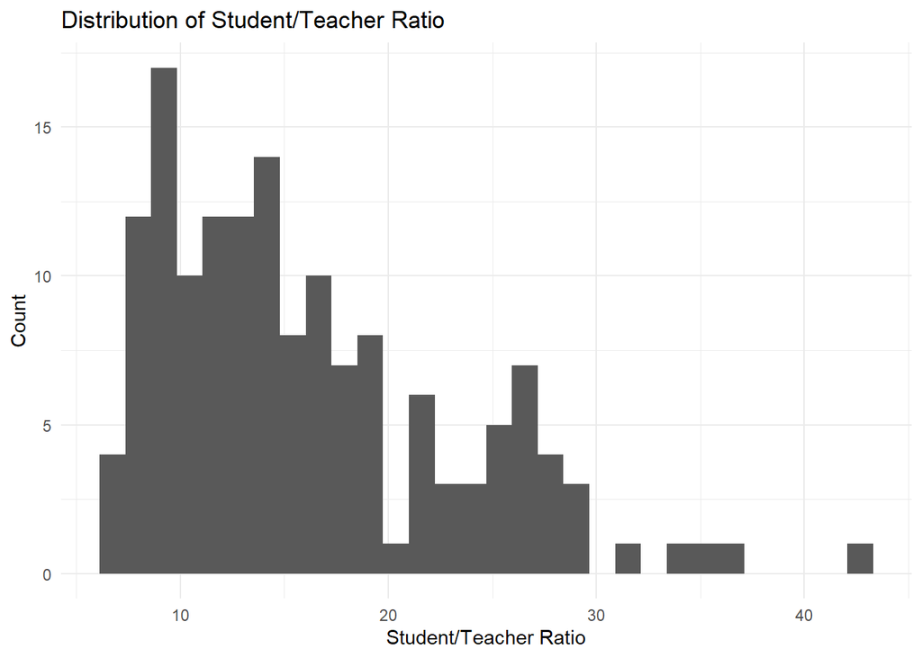

```r
ggplot(ratio_gdp_2016, aes(x = student_ratio)) +
  geom_histogram(bins = 30) +
  labs(
    title = "Distribution of Student/Teacher Ratio",
    x = "Student/Teacher Ratio",
    y = "Count"
  ) +
  theme_minimal()
```

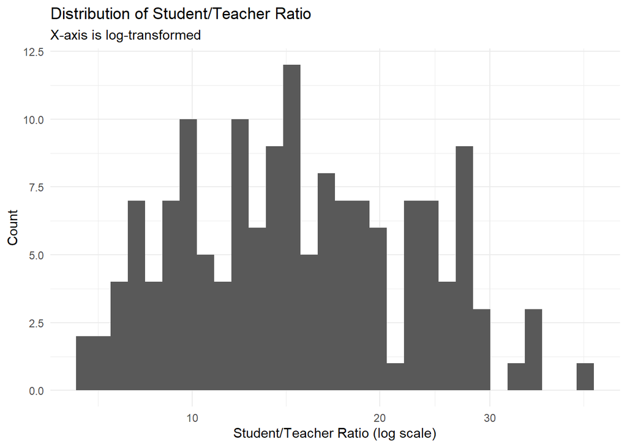

```r
ggplot(ratio_gdp_2016, aes(x = student_ratio)) +
  geom_histogram(bins = 30) +
  scale_x_log10() +
  labs(
    title = "Distribution of Student/Teacher Ratio",
    subtitle = "X-axis is log-transformed",
    x = "Student/Teacher Ratio (log scale)",
    y = "Count"
  ) +
  theme_minimal()
```

## Q7.4

This chart compares GDP per capita with the student/teacher ratio. I mapped population to the size of the points and region to color so the relationship is easier to compare across countries.

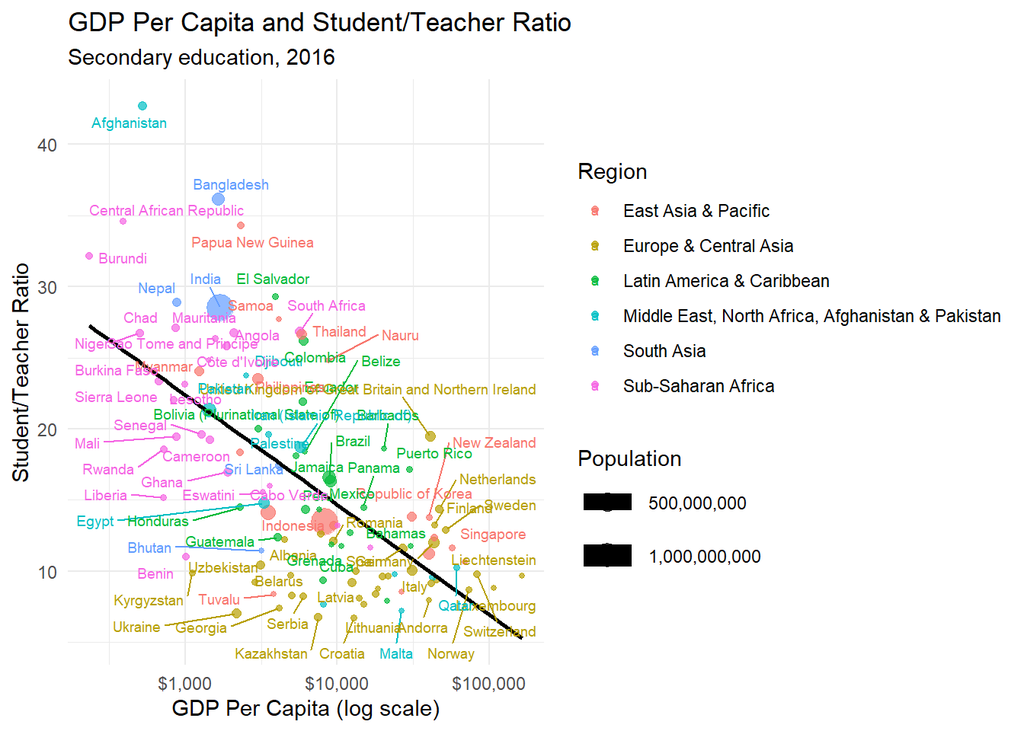

```r
ratio_gdp_2016 |>
  filter(
    !is.na(gdp_per_capita),
    !is.na(population),
    !is.na(region)
  ) |>
  ggplot(
    aes(
      x = gdp_per_capita,
      y = student_ratio,
      size = population,
      color = region,
      label = country.x
    )
  ) +
  geom_point(alpha = 0.7) +
  geom_smooth(
    method = "lm",
    se = FALSE,
    color = "black"
  ) +
  geom_text_repel(
    size = 2.5,
    max.overlaps = 20
  ) +
  scale_x_log10(labels = dollar_format()) +
  scale_size_continuous(labels = comma) +
  labs(
    title = "GDP Per Capita and Student/Teacher Ratio",
    subtitle = "Secondary education, 2016",
    x = "GDP Per Capita (log scale)",
    y = "Student/Teacher Ratio",
    color = "Region",
    size = "Population"
  ) +
  theme_minimal()
```

## Q7.5

For the final chart in this question, I separated the GDP and student/teacher ratio relationship by region. This makes it easier to compare whether the pattern looks different across world regions.

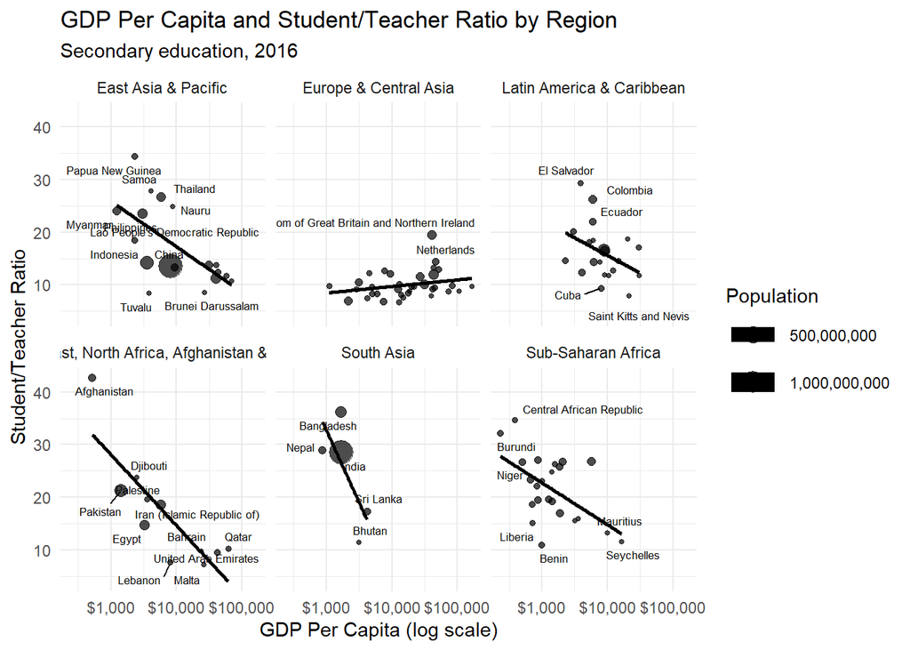

```r
ratio_gdp_2016 |>
  filter(
    !is.na(gdp_per_capita),
    !is.na(population),
    !is.na(region)
  ) |>
  ggplot(
    aes(
      x = gdp_per_capita,
      y = student_ratio,
      size = population,
      label = country.x
    )
  ) +
  geom_point(alpha = 0.7) +
  geom_smooth(
    method = "lm",
    se = FALSE,
    color = "black"
  ) +
  geom_text_repel(
    size = 2.2,
    max.overlaps = 10
  ) +
  scale_x_log10(labels = dollar_format()) +
  scale_size_continuous(labels = comma) +
  facet_wrap(~region) +
  labs(
    title = "GDP Per Capita and Student/Teacher Ratio by Region",
    subtitle = "Secondary education, 2016",
    x = "GDP Per Capita (log scale)",
    y = "Student/Teacher Ratio",
    size = "Population"
  ) +
  theme_minimal()
```

# Question 8: Labelled data

## Q8.1

For this question, I imported the `demo.sav` SPSS dataset using the `haven` package. Since this file contains labelled data, I also viewed the variable labels and value labels to better understand what the coded variables mean.

```r
demo <- read_sav("data/demo.sav")

# Examine the dataset
glimpse(demo)
```

```
Rows: 6,400
Columns: 29
$ age      <dbl> 55, 56, 28, 24, 25, 45, 42, 35, 46, 34, 55, 28, 31, 42, 35, 5…
$ marital  <dbl+lbl> 1, 0, 1, 1, 0, 1, 0, 0, 0, 1, 1, 0, 1, 0, 0, 1, 1, 0, 0, …
$ address  <dbl> 12, 29, 9, 4, 2, 9, 19, 15, 26, 0, 17, 3, 9, 8, 8, 24, 1, 0, …
$ income   <dbl> 72, 153, 28, 26, 23, 76, 40, 57, 24, 89, 72, 24, 40, 137, 70,…
$ inccat   <dbl+lbl> 3, 4, 2, 2, 1, 4, 2, 3, 1, 4, 3, 1, 2, 4, 3, 4, 2, 2, 4, …
$ car      <dbl> 36.2, 76.9, 13.7, 12.5, 11.3, 37.2, 19.8, 28.2, 12.2, 46.1, 3…
$ carcat   <dbl+lbl> 3, 3, 1, 1, 1, 3, 2, 2, 1, 3, 3, 1, 2, 3, 3, 3, 2, 1, 3, …
$ ed       <dbl+lbl> 1, 1, 3, 4, 2, 3, 3, 2, 1, 3, 3, 4, 4, 3, 3, 4, 3, 1, 3, …
$ employ   <dbl> 23, 35, 4, 0, 5, 13, 10, 1, 11, 12, 2, 4, 0, 3, 9, 16, 0, 2, …
$ retire   <dbl+lbl> 0, 0, 0, 0, 0, 0, 0, 0, 0, 0, 0, 0, 0, 0, 0, 0, 0, 0, 0, …
$ empcat   <dbl+lbl> 3, 3, 1, 1, 2, 2, 2, 1, 2, 2, 1, 1, 1, 1, 2, 3, 1, 1, 3, …
$ jobsat   <dbl+lbl> 5, 4, 3, 1, 2, 2, 2, 1, 5, 4, 3, 5, 2, 1, 4, 5, 1, 4, 3, …
$ gender   <chr+lbl> "f", "m", "f", "m", "m", "m", "m", "f", "f", "m", "f", "m…
```

[output cut: 16 more lines]

```r
# Print the dataset
demo
```

```
# A tibble: 6,400 × 29
     age marital      address income inccat    car carcat  ed      employ retire
   <dbl> <dbl+lbl>      <dbl>  <dbl> <dbl+l> <dbl> <dbl+l> <dbl+l>  <dbl> <dbl+>
 1    55 1 [Married]       12     72 3 [$50…  36.2 3 [Lux… 1 [Did…     23 0 [No]
 2    56 0 [Unmarrie…      29    153 4 [$75…  76.9 3 [Lux… 1 [Did…     35 0 [No]
 3    28 1 [Married]        9     28 2 [$25…  13.7 1 [Eco… 3 [Som…      4 0 [No]
 4    24 1 [Married]        4     26 2 [$25…  12.5 1 [Eco… 4 [Col…      0 0 [No]
 5    25 0 [Unmarrie…       2     23 1 [Und…  11.3 1 [Eco… 2 [Hig…      5 0 [No]
 6    45 1 [Married]        9     76 4 [$75…  37.2 3 [Lux… 3 [Som…     13 0 [No]
 7    42 0 [Unmarrie…      19     40 2 [$25…  19.8 2 [Sta… 3 [Som…     10 0 [No]
 8    35 0 [Unmarrie…      15     57 3 [$50…  28.2 2 [Sta… 2 [Hig…      1 0 [No]
 9    46 0 [Unmarrie…      26     24 1 [Und…  12.2 1 [Eco… 1 [Did…     11 0 [No]
10    34 1 [Married]        0     89 4 [$75…  46.1 3 [Lux… 3 [Som…     12 0 [No]
# ℹ 6,390 more rows
# ℹ 19 more variables: empcat <dbl+lbl>, jobsat <dbl+lbl>, gender <chr+lbl>,
#   reside <dbl>, wireless <dbl+lbl>, multline <dbl+lbl>, voice <dbl+lbl>,
#   pager <dbl+lbl>, internet <dbl+lbl>, callid <dbl+lbl>, callwait <dbl+lbl>,
#   owntv <dbl+lbl>, ownvcr <dbl+lbl>, owncd <dbl+lbl>, ownpda <dbl+lbl>,
#   ownpc <dbl+lbl>, ownfax <dbl+lbl>, news <dbl+lbl>, response <dbl+lbl>
```

```r
# View variable labels and value labels
look_for(demo)
```

```
 pos variable label                   col_type missing values
 1   age      Age in years            dbl      0
 2   marital  Marital status          dbl+lbl  0       [0] Unmarried
                                                       [1] Married
 3   address  Years at current addre~ dbl      0
 4   income   Household income in th~ dbl      0
 5   inccat   Income category in tho~ dbl+lbl  0       [1] Under $25
                                                       [2] $25 - $49
                                                       [3] $50 - $74
                                                       [4] $75+
 6   car      Price of primary vehic~ dbl      0
 7   carcat   Primary vehicle price ~ dbl+lbl  0       [1] Economy
                                                       [2] Standard
                                                       [3] Luxury
 8   ed       Level of education      dbl+lbl  0       [1] Did not complete h~
```

[output cut: 50 more lines]

## Q8.2

```r
# Employment status table

demo |>
  mutate(employ = as_factor(employ)) |>
  count(employ) |>
  mutate(percent = n / sum(n))
```

```
# A tibble: 53 × 3
   employ     n percent
   <fct>  <int>   <dbl>
 1 0        680  0.106
 2 1        435  0.0680
 3 2        391  0.0611
 4 3        380  0.0594
 5 4        330  0.0516
 6 5        335  0.0523
 7 6        282  0.0441
 8 7        256  0.04
 9 8        268  0.0419
10 9        237  0.0370
# ℹ 43 more rows
```

```r
# Retirement status table

demo |>
  mutate(retire = as_factor(retire)) |>
  count(retire) |>
  mutate(percent = n / sum(n))
```

```
# A tibble: 2 × 3
  retire     n percent
  <fct>  <int>   <dbl>
1 0       6092  0.952
2 1        308  0.0481
```

```r
# Employment category table

demo |>
  mutate(empcat = as_factor(empcat)) |>
  count(empcat) |>
  mutate(percent = n / sum(n))
```

```
# A tibble: 3 × 3
  empcat     n percent
  <fct>  <int>   <dbl>
1 1       2216   0.346
2 2       2364   0.369
3 3       1820   0.284
```

```r
# Job satisfaction table

demo |>
  mutate(jobsat = as_factor(jobsat)) |>
  count(jobsat) |>
  mutate(percent = n / sum(n))
```

```
# A tibble: 5 × 3
  jobsat     n percent
  <fct>  <int>   <dbl>
1 1       1109   0.173
2 2       1268   0.198
3 3       1393   0.218
4 4       1406   0.220
5 5       1224   0.191
```

## Q8.3

```r
job_tech_count <- demo |>
  select(
    wireless,
    multline,
    voice,
    pager,
    internet,
    callid,
    callwait
  ) |>
  mutate(across(everything(), as_factor)) |>
  pivot_longer(
    cols = everything(),
    names_to = "technology",
    values_to = "ownership"
  ) |>
  filter(ownership == "Yes") |>
  count(technology, ownership)

job_tech_count
```

```
# A tibble: 0 × 3
# ℹ 3 variables: technology <chr>, ownership <fct>, n <int>
```

[figure not shown]

```r
ggplot(job_tech_count, aes(x = reorder(technology, n), y = n)) +
  geom_col() +
  coord_flip() +
  labs(
    title = "Count of Job-Related Technology Ownership",
    subtitle = "Based on the demo.sav labelled dataset",
    x = "Technology Product",
    y = "Count"
  ) +
  theme_minimal()
```

# Question 9: Impact of retirement on the use of the total job-related technology products

## Q9.1

```r
demo <- demo |>
  mutate(
    total_job_tech =
      as.numeric(as_factor(wireless) == "Yes") +
      as.numeric(as_factor(multline) == "Yes") +
      as.numeric(as_factor(voice) == "Yes") +
      as.numeric(as_factor(pager) == "Yes") +
      as.numeric(as_factor(internet) == "Yes") +
      as.numeric(as_factor(callid) == "Yes") +
      as.numeric(as_factor(callwait) == "Yes")
  )

var_label(demo$total_job_tech) <- "Total number of job-related technology products used"

demo |>
  select(
    wireless,
    multline,
    voice,
    pager,
    internet,
    callid,
    callwait,
    total_job_tech
  )
```

```
# A tibble: 6,400 × 8
   wireless  multline  voice    pager   internet callid  callwait total_job_tech
   <dbl+lbl> <dbl+lbl> <dbl+lb> <dbl+l> <dbl+lb> <dbl+l> <dbl+lb>          <dbl>
 1 0 [No]    0 [No]    1 [Yes]  0 [No]  0 [No]   0 [No]  0 [No]                0
 2 1 [Yes]   0 [No]    1 [Yes]  1 [Yes] 0 [No]   1 [Yes] 1 [Yes]               0
 3 1 [Yes]   0 [No]    1 [Yes]  0 [No]  0 [No]   1 [Yes] 1 [Yes]               0
 4 1 [Yes]   1 [Yes]   1 [Yes]  0 [No]  0 [No]   0 [No]  1 [Yes]               0
 5 0 [No]    0 [No]    0 [No]   0 [No]  0 [No]   1 [Yes] 0 [No]                0
 6 0 [No]    1 [Yes]   1 [Yes]  1 [Yes] 0 [No]   0 [No]  0 [No]                0
 7 1 [Yes]   1 [Yes]   1 [Yes]  0 [No]  1 [Yes]  1 [Yes] 0 [No]                0
 8 0 [No]    0 [No]    0 [No]   0 [No]  0 [No]   0 [No]  0 [No]                0
 9 0 [No]    0 [No]    1 [Yes]  0 [No]  0 [No]   1 [Yes] 0 [No]                0
10 1 [Yes]   0 [No]    1 [Yes]  0 [No]  0 [No]   1 [Yes] 1 [Yes]               0
# ℹ 6,390 more rows
```

## Q9.2

Next, I created tables showing the average number of job-related technology products by retirement status, employment category, and job satisfaction.

```r
demo |>
  mutate(retire = as_factor(retire)) |>
  group_by(retire) |>
  summarise(
    average_total_job_tech = mean(total_job_tech, na.rm = TRUE),
    n = n()
  )
```

```
# A tibble: 2 × 3
  retire average_total_job_tech     n
  <fct>                   <dbl> <int>
1 0                           0  6092
2 1                           0   308
```

```r
demo |>
  mutate(empcat = as_factor(empcat)) |>
  group_by(empcat) |>
  summarise(
    average_total_job_tech = mean(total_job_tech, na.rm = TRUE),
    n = n()
  )
```

```
# A tibble: 3 × 3
  empcat average_total_job_tech     n
  <fct>                   <dbl> <int>
1 1                           0  2216
2 2                           0  2364
3 3                           0  1820
```

```r
demo |>
  mutate(jobsat = as_factor(jobsat)) |>
  group_by(jobsat) |>
  summarise(
    average_total_job_tech = mean(total_job_tech, na.rm = TRUE),
    n = n()
  )
```

```
# A tibble: 5 × 3
  jobsat average_total_job_tech     n
  <fct>                   <dbl> <int>
1 1                           0  1109
2 2                           0  1268
3 3                           0  1393
4 4                           0  1406
5 5                           0  1224
```

# Question 10: Job-related technology product ownership

## Q10

[figure not shown]

```r
tech_summary <- demo |>
  select(
    wireless,
    multline,
    voice,
    pager,
    internet,
    callid,
    callwait
  ) |>
  mutate(across(everything(), ~ as_factor(.) == "Yes")) |>
  pivot_longer(
    cols = everything(),
    names_to = "technology",
    values_to = "ownership"
  ) |>
  group_by(technology) |>
  summarise(
    proportion = mean(ownership, na.rm = TRUE),
    n = sum(!is.na(ownership)),
    se = sqrt(proportion * (1 - proportion) / n),
    lower = proportion - 1.96 * se,
    upper = proportion + 1.96 * se
  ) |>
  arrange(desc(proportion))

tech_summary$technology <-
  factor(
    tech_summary$technology,
    levels = tech_summary$technology
  )

ggplot(
  tech_summary,
  aes(
    x = technology,
    y = proportion
  )
) +
  geom_col(fill = "steelblue") +
  geom_errorbar(
    aes(
      ymin = lower,
      ymax = upper
    ),
    width = 0.2
  ) +
  geom_text(
    aes(
      label = scales::percent(
        proportion,
        accuracy = 0.1
      )
    ),
    vjust = -0.5,
    size = 4
  ) +
  scale_y_continuous(
    labels = scales::percent,
    limits = c(0, 1)
  ) +
  labs(
    title = "Ownership of Job-Related Technology Products",
    subtitle = "Proportion of participants owning each product (95% confidence intervals)",
    x = "Technology Product",
    y = "Proportion of Participants"
  ) +
  theme_minimal()
```